# Python for Basketball Statistics

## Getting some data

We will be working with NBA basketball data from the 2018-2019 season downloaded from [nbastuffer.com](https://www.nbastuffer.com/2018-2019-nba-player-stats/).  
Let's load the data into a Pandas dataframe.

```python
import pandas as pd
nba_df = pd.read_csv("NBA_player_stats_18-19.csv")
nba_df.head(5)
```

|  | FULL_NAME | TEAM | POS | AGE | GP | MPG | MIN.pct | USG.pct | TOR | FTA | ... | RPG | TRB.pct | APG | AST.pct | SPG | BPG | TOPG | VI | ORTG | DRTG |
| --- | --- | --- | --- | --- | --- | --- | --- | --- | --- | --- | --- | --- | --- | --- | --- | --- | --- | --- | --- | --- | --- |
| 0 | James Harden | Hou | G | 29.63 | 78 | 36.8 | 76.6 | 40.5 | 14.5 | 858 | ... | 6.6 | 10.0 | 7.5 | 39.5 | 2.05 | 0.73 | 4.96 | 13.2 | 118.6 | 103.5 |
| 1 | Paul George | Okc | F | 28.94 | 77 | 36.9 | 76.9 | 29.5 | 10.0 | 539 | ... | 8.1 | 11.4 | 4.1 | 17.7 | 2.21 | 0.44 | 2.66 | 10.6 | 116.5 | 100.8 |
| 2 | Giannis Antetokounmpo | Mil | F | 24.35 | 72 | 32.8 | 68.2 | 32.3 | 14.7 | 686 | ... | 12.5 | 19.4 | 5.9 | 30.3 | 1.26 | 1.53 | 3.71 | 15.5 | 121.6 | 93.9 |
| 3 | Joel Embiid | Phi | F-C | 25.07 | 64 | 33.7 | 70.1 | 33.3 | 13.3 | 649 | ... | 13.6 | 21.4 | 3.7 | 18.4 | 0.72 | 1.91 | 3.55 | 13.2 | 113.7 | 98.7 |
| 4 | LeBron James | Lal | F | 34.28 | 55 | 35.2 | 73.4 | 31.6 | 13.3 | 418 | ... | 8.4 | 12.3 | 8.3 | 39.4 | 1.31 | 0.60 | 3.58 | 14.1 | 114.4 | 106.2 |

5 rows × 28 columns

The data has 28 statistics for 622 players.

```python
nba_df.shape
```

```
(622, 28)
```

## Cleaning the data

Let's check the percentage of missing observations in each row.

```python
round(
    nba_df.isna().sum() / nba_df.count() * 100
)
```

```
FULL_NAME    0.0
TEAM         0.0
POS          0.0
AGE          0.0
GP           0.0
MPG          0.0
MIN.pct      0.0
USG.pct      0.0
TOR          1.0
FTA          0.0
FT.pct       0.0
2PA          0.0
2P.pct       0.0
3PA          0.0
3P.pct       0.0
eFG.pct      1.0
TS.pct       1.0
PPG          0.0
RPG          0.0
TRB.pct      0.0
APG          0.0
AST.pct      0.0
SPG          0.0
BPG          0.0
TOPG         0.0
VI           0.0
ORTG         4.0
DRTG         4.0
dtype: float64
```

This is a problem considering I plan to use the defensive rating statistic (DRRTG) which has 4% missing values.  
Let's have a look at which players have missing data.

```python
unlucky_players =  nba_df[nba_df.isna().any(axis=1)]
unlucky_players.FULL_NAME
```

```
518               Greg Monroe
537              Troy Caupain
561                   Zhou Qi
576              Trevon Duval
579              Thomas Welsh
582              John Jenkins
587           Brandon Goodwin
594             Emanuel Terry
595    DeVaughn Akoon-Purcell
597            Terrence Jones
603               Tyler Lydon
605           Tyler Cavanaugh
609              Ike Anigbogu
610             Eric Moreland
611               George King
612               Tyler Davis
613               Okaro White
614              Andre Ingram
615               Zach Lofton
616              Kobi Simmons
617              Ray Spalding
618            Donte Grantham
619                Tyler Ulis
620              John Holland
621               Jawun Evans
Name: FULL_NAME, dtype: object
```

Based on my NBA knowledge, these players all look like guys who don't play much, so they probably won't pass my minutes per game threshold anyway. Let's have a look at their minutes per game.  
Here, I am deliberately scaling the x-axis to include 48 minutes which is the length of an NBA game.

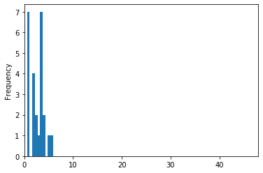

```python
mpg = unlucky_players.MPG.plot.hist()
mpg.set_xlim(0,48);
```

## Problem statement

The question I'm interested in is this: do the two most frequently used individual defensive statistics, steals and blocks, actually correlate with good defensive ability.

The gold standard for defensive ability I will be using is the defensive rating (DRTG). It is very complicated to calculate and it estimates how many points a player allows per 100 posessions they are on the floor. A lower DRTG means a better defender.

Let's take a look at the distribution of DRTG in the dataset.

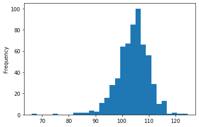

```python
nba_df.DRTG.plot.hist(bins = 30);
```

It seems to be distributed mostly between 100 and 110 which makes sense considering the league average was 110 points per 100 posessions in the 2018-2019 season.

As a gut check for the DRTG statistic, let's make sure the Defensive Player of the Year from 2018-2019 season has a good DRTG.

```python
nba_df[nba_df.FULL_NAME == "Rudy Gobert"]
```

|  | FULL_NAME | TEAM | POS | AGE | GP | MPG | MIN.pct | USG.pct | TOR | FTA | ... | RPG | TRB.pct | APG | AST.pct | SPG | BPG | TOPG | VI | ORTG | DRTG |
| --- | --- | --- | --- | --- | --- | --- | --- | --- | --- | --- | --- | --- | --- | --- | --- | --- | --- | --- | --- | --- | --- |
| 77 | Rudy Gobert | Uta | C | 26.79 | 81 | 31.8 | 66.3 | 17.8 | 12.1 | 522 | ... | 12.8 | 21.8 | 2.0 | 9.6 | 0.81 | 2.3 | 1.6 | 9.3 | 133.8 | 96.7 |

1 rows × 28 columns

A DRTG of 96.7 passes the gut check. I think some of the outliers with very low DRTG may be playing few minutes per game.

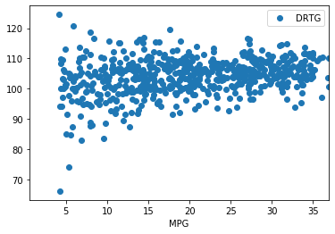

```python
nba_df.plot(x = "MPG", y = "DRTG", style = 'o');
```

It seems so. The outlying very good defenders and very bad defenders mostly play less than 15 minutes per game. To look at defensive statistics, we will only consider players who played more than 20 minutes per game.

```python
nba_df_sub = nba_df[nba_df.MPG > 20]
sub_pct = round( nba_df_sub.shape[0] / nba_df.shape[0] * 100, 2)
f"Retaining {nba_df_sub.shape[0]} players or {sub_pct}% of players."
```

```
'Retaining 287 players or 46.14% of players.'
```

It may seem strange to a data scientist to throw out more than half of your data. However, a typical NBA team has an 8-man rotation of players that rotate in and out. So for a league of 30 teams, we are looking for a dataset of approximatelt 240 players to focus on those who play consistent minutes.

## Do steals and blocks correlate with DRTG?

I am going to use the seaborn module to create nice plots and I will use the scipy stats module to create a function to calculate R-squared to display on the plot.

```python
import seaborn as sns
from scipy import stats
def r2(x, y):
    return stats.pearsonr(x, y)[0] ** 2
```

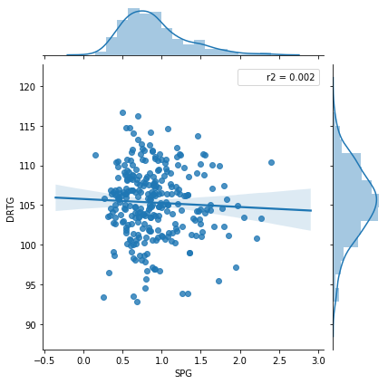

```python
sns.jointplot(x=nba_df_sub.SPG, y=nba_df_sub.DRTG, kind = "reg", stat_func=r2);
```

It does not look like there is any correlation between steals per game and defensive rating.

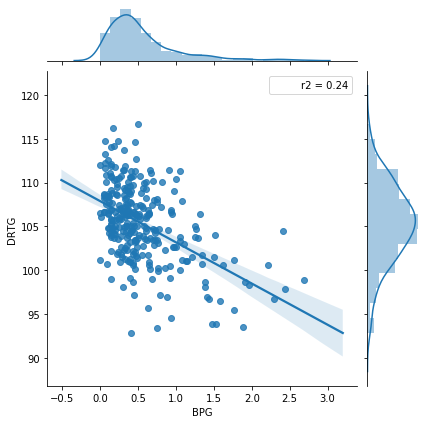

```python
sns.jointplot(x=nba_df_sub.BPG, y=nba_df_sub.DRTG, kind = "reg", stat_func=r2);
```

Very interesting! Blocks per game do have some correlation with defensive rating. It does look like the correlation is driven by a small number of players with high blocks per game. The distribution of the BPG statistic makes me think that the defensive statistic might be position biased.

## Adding one layer of detail: considering by position

Let's look at the DRTG by position. On first pass, there was some inconsistent labeling of the positions so I will fix that below.

```python
nba_df_clean = nba_df_sub
nba_df_clean["POS"].replace({"F-G": "G-F", "C-F": "F-C"}, inplace=True)
```

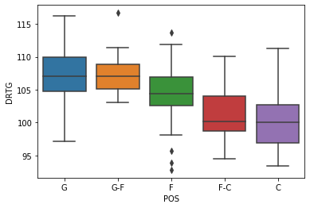

```python
sns.boxplot(x=nba_df_clean.POS, y=nba_df_clean.DRTG, order = ["G","G-F","F","F-C","C"]);
```

It looks like there is a clear bias in the defensive rating towards forwards and centers. Based on the distribution, I will consider 3 groups:

1. Guard and Guard/Forwards
2. Forwards
3. Forward/Centers and Centers

```python
nba_guards = nba_df_clean.query('POS == "G" or POS == "G-F"')
nba_forwards = nba_df_clean[nba_df_clean.POS == "F"]
nba_centers = nba_df_clean.query('POS == "C" or POS == "F-C"')
```

Let's see if the correlations change when we consider by position.

### Guards

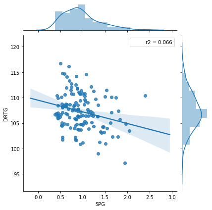

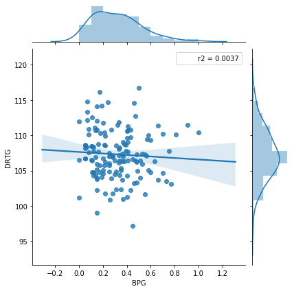

```python
sns.jointplot(x=nba_guards.SPG, y=nba_guards.DRTG, kind = "reg", stat_func=r2);
sns.jointplot(x=nba_guards.BPG, y=nba_guards.DRTG, kind = "reg", stat_func=r2);
```

### Forwards

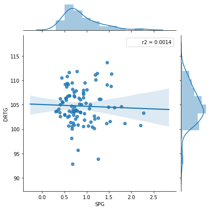

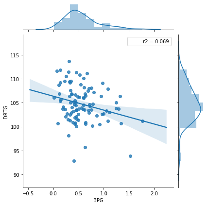

```python
sns.jointplot(x=nba_forwards.SPG, y=nba_forwards.DRTG, kind = "reg", stat_func=r2);
sns.jointplot(x=nba_forwards.BPG, y=nba_forwards.DRTG, kind = "reg", stat_func=r2);
```

### Centers

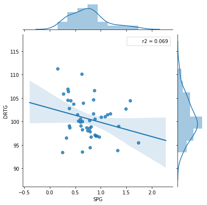

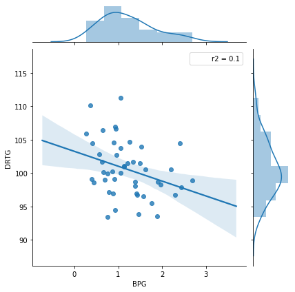

```python
sns.jointplot(x=nba_centers.SPG, y=nba_centers.DRTG, kind = "reg", stat_func=r2);
sns.jointplot(x=nba_centers.BPG, y=nba_centers.DRTG, kind = "reg", stat_func=r2);
```